[figure not shown]

# Day 15/100 of Data Science

# Model Evaluation Techniques

## What is a Confusion Matrix?

- A confusion matrix is a matrix that summarizes the performance of a machine learning model on a set of test data.
- It is a means of displaying the number of accurate and inaccurate instances based on the model’s predictions.
- A Confusion matrix is an N x N matrix used for evaluating the performance of a classification model, where N is the number of target classes.
- The matrix compares the actual target values with those predicted by the machine learning model.

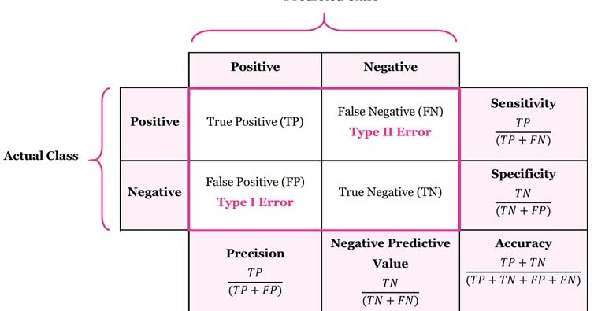

The matrix displays the number of instances produced by the model on the test data.

## Accuracy

- Accuracy is a metric that measures how often a machine learning model correctly predicts the outcome

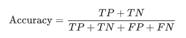

## Precision

- Precision is one indicator of a machine learning model's performance – the quality of a positive prediction made by the model.
- Precision refers to the number of true positives divided by the total number of positive predictions

## Recall or Sensitivity

- The recall is the measure of our model correctly identifying True Positives.

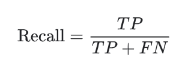

## F1 score

- F1 score is a measure of the harmonic mean of precision and recall.
- Commonly used as an evaluation metric in binary and multi-class classification

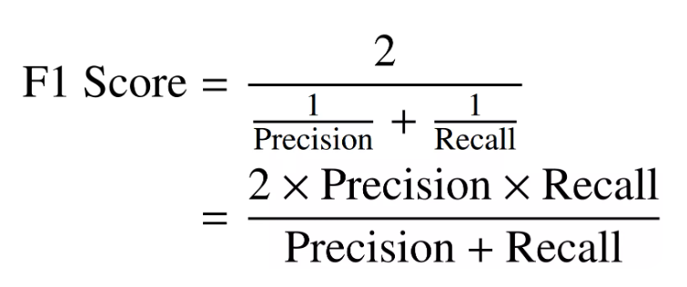

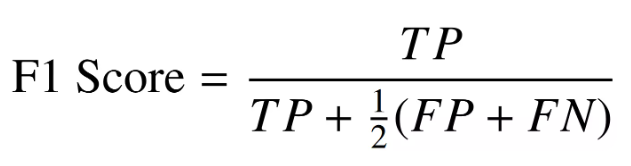

## Specificity

- Specificity itself can be described as the algorithm/model's ability to predict a true negative of each category available.

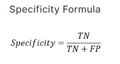

## ROC curve

An ROC curve (receiver operating characteristic curve) is a graph showing the performance of a classification model at all classification thresholds. This curve plots two parameters:

- True Positive Rate
- False Positive Rate

- An ROC curve plots TPR vs. FPR at different classification thresholds.
- Lowering the classification threshold classifies more items as positive, thus increasing both False Positives and True Positives.
- The following figure shows a typical ROC curve.

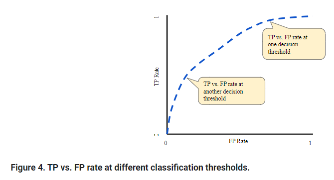

## AUC: Area Under the ROC Curve

- AUC stands for "Area under the ROC Curve."
- That is, AUC measures the entire two-dimensional area underneath the entire ROC curve (think integral calculus) from (0,0) to (1,1).

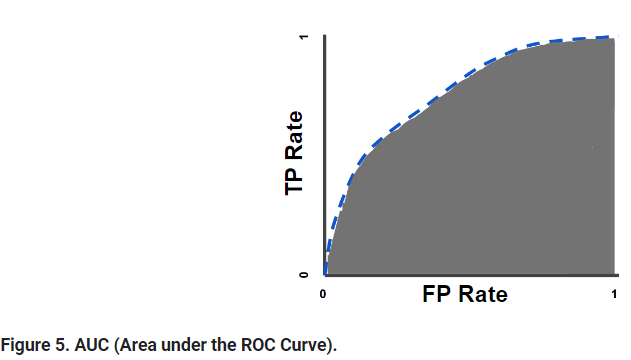

# Mean Squared Error

- In Statistics, Mean Squared Error (MSE) is defined as Mean or Average of the square of the difference between actual and estimated values.

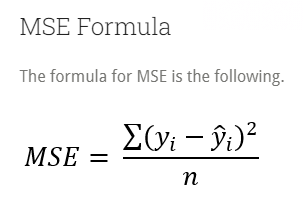

Where:

- yi is the ith observed value.
- ŷi is the corresponding predicted value.
- n = the number of observations.

## The Root Mean Squared Error (RMSE)

- The Root Mean Squared Error (RMSE) is one of the two main performance indicators for a regression model.
- It measures the average difference between values predicted by a model and the actual values.
- It provides an estimation of how well the model is able to predict the target value (accuracy).

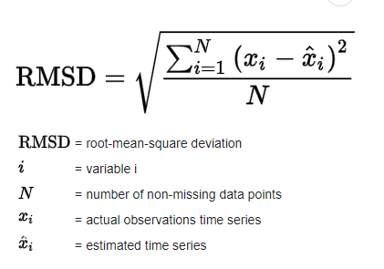

## R squared (R2)

- R squared (R2) is a regression error metric that justifies the performance of the model.
- It represents the value of how much the independent variables are able to describe the value for the response/target variable.

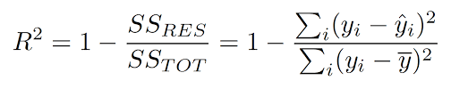

[figure not shown]

## Mean Absolute Error (MAE)

- It is the arithmetic average of the absolute difference between predicted and actual values

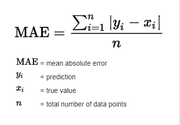

[figure not shown]

# Follow us on Social Media

Linkedin: https://www.linkedin.com/company/eternaltek/about/?viewAsMember=true

Medium: https://medium.com/@eternaltek.info

WhatsApp Channel: https://whatsapp.com/channel/0029Va5onCbDjiOTi6D1vU36

Github: https://github.com/Vamsi-2203